# Time Slice Photography

### Author: mcswe | https://github.com/mcswe

```python
import pandas as pd
import numpy as np
import imageio
import matplotlib.pyplot as plt
```

### Slicing Directly Across Time

I will fix a column of 450 images and stack them together to produce a singular image.

The following CSV file contains an index of the `plaza` image set that contains frames of a video broken out into individual images. The index has columns for just the Filename and the full URL where the image lives.

```python
plaza_index = pd.read_csv("https://facultyweb.cs.wwu.edu/~wehrwes/courses/data311_21f/data/plaza.csv")
plaza_index
```

|  | Filename | URL |
| --- | --- | --- |
| 0 | plaza0001.png | https://facultyweb.cs.wwu.edu/~wehrwes/courses... |
| 1 | plaza0002.png | https://facultyweb.cs.wwu.edu/~wehrwes/courses... |
| 2 | plaza0003.png | https://facultyweb.cs.wwu.edu/~wehrwes/courses... |
| 3 | plaza0004.png | https://facultyweb.cs.wwu.edu/~wehrwes/courses... |
| 4 | plaza0005.png | https://facultyweb.cs.wwu.edu/~wehrwes/courses... |
| ... | ... | ... |
| 445 | plaza0446.png | https://facultyweb.cs.wwu.edu/~wehrwes/courses... |
| 446 | plaza0447.png | https://facultyweb.cs.wwu.edu/~wehrwes/courses... |
| 447 | plaza0448.png | https://facultyweb.cs.wwu.edu/~wehrwes/courses... |
| 448 | plaza0449.png | https://facultyweb.cs.wwu.edu/~wehrwes/courses... |
| 449 | plaza0450.png | https://facultyweb.cs.wwu.edu/~wehrwes/courses... |

450 rows × 2 columns

The first thing I will do is put all of the frames into a NumPy array, as NumPy allows for multidimensional arrays. I will do this by:

1. Traversing the "URL" column of the plaza index
2. Using the imageio.imread() function to acquire the frames (images) from the URL
3. Putting those images in a list
4. Converting that list into a numpy array

```python
all_frames = []
for image in plaza_index["URL"]: # iterating thru urls
    all_frames.append(imageio.imread(image)) # read the image of the url, then append it to array
arr = np.array(all_frames)
```

Now I will fix the column dimension (i.e. make stationary) but modify all rows, frames, and color channels. I will do this by using a colon (:) to index the multidimensional numpy array. A colon (:) means "select all indices along this axis."

When displaying this new image, the image will be rotated. To fix this, I will rotate it using the `transpose()` function. If we think of the rotated image's values with axes (0, 1, 2), 0 representing rows, 1 representing columns, and 2 representing color channels, we need to flip the row and column axes to rotate the image.

I will display this newly rotated, up-right image using the matplot `imshow()` function.

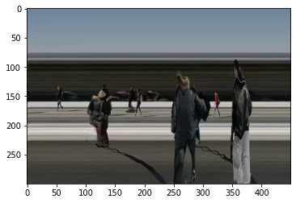

```python
fix_cols = arr[:,:,50,:]
rotate = fix_cols.transpose((1, 0, 2))
plt.imshow(rotate)
```

### Slicing Diagonally Across Time and Space

Now I will compute a *diagonal* time slice image of the New York skyline.

The following CSV file contains an index of the `ny` image set that contains frames of a video broken out into individual images. The index has columns for just the Filename and the full URL where the image lives.

```python
ny_index = pd.read_csv("https://facultyweb.cs.wwu.edu/~wehrwes/courses/data311_21f/data/ny.csv")
ny_index
```

|  | Filename | URL |
| --- | --- | --- |
| 0 | ny0001.png | https://facultyweb.cs.wwu.edu/~wehrwes/courses... |
| 1 | ny0002.png | https://facultyweb.cs.wwu.edu/~wehrwes/courses... |
| 2 | ny0003.png | https://facultyweb.cs.wwu.edu/~wehrwes/courses... |
| 3 | ny0004.png | https://facultyweb.cs.wwu.edu/~wehrwes/courses... |
| 4 | ny0005.png | https://facultyweb.cs.wwu.edu/~wehrwes/courses... |
| ... | ... | ... |
| 833 | ny0834.png | https://facultyweb.cs.wwu.edu/~wehrwes/courses... |
| 834 | ny0835.png | https://facultyweb.cs.wwu.edu/~wehrwes/courses... |
| 835 | ny0836.png | https://facultyweb.cs.wwu.edu/~wehrwes/courses... |
| 836 | ny0837.png | https://facultyweb.cs.wwu.edu/~wehrwes/courses... |
| 837 | ny0838.png | https://facultyweb.cs.wwu.edu/~wehrwes/courses... |

838 rows × 2 columns

Now I will put all of the frames into a NumPy array.

```python
all_frames2 = []
for image in ny_index["URL"]: # iterating thru urls
    all_frames2.append(imageio.imread(image)) # read the image of the url, then append it to array
arr = np.array(all_frames2)
```

The final image will come out rotated again, so I will transpose like I did earlier.

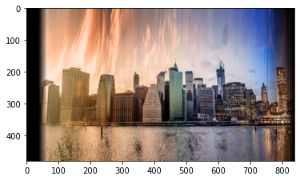

```python
cols = []
for i in range(838):
    cols.append(arr[i, :, i, :])
diag = np.array(cols)

rotate2 = diag.transpose((1, 0, 2))
plt.imshow(rotate2)
```